# Cabinet Churn & Democratic Erosion

Country-years

9,269

Avg. turnover, autocracies

30.4%

Avg. turnover, democracies

35.3%

Cabinet turnover vs. polyarchy, by decade (country-decade means)

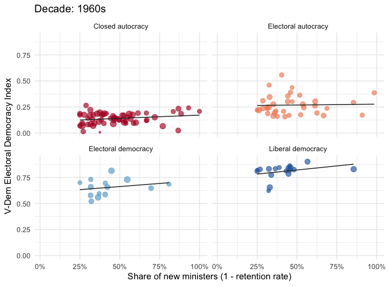

All country-years pooled (with LOESS fit)

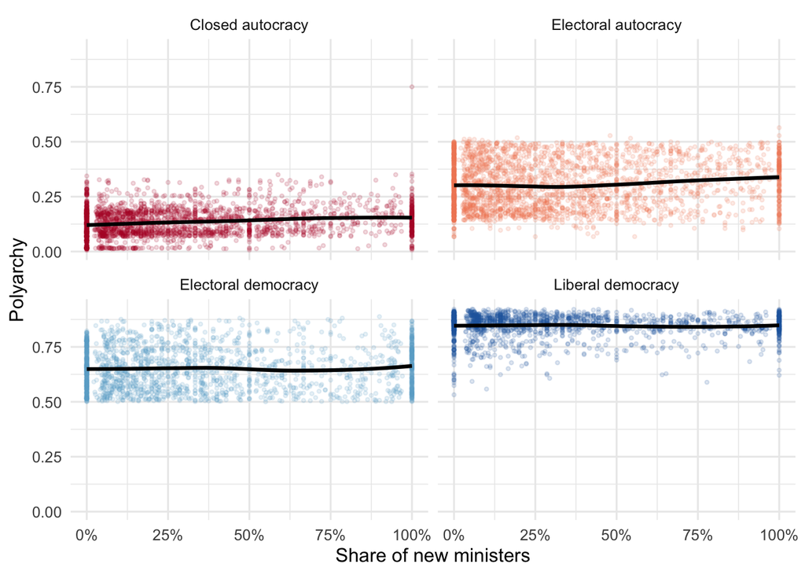

Turnover by regime type

| Regime | Country-years | Mean turnover | Median turnover | Years with >50% new |
| --- | --- | --- | --- | --- |
| Closed autocracy | 2569 | 30.0% | 19.0% | 22.8% |
| Electoral autocracy | 2857 | 30.8% | 21.1% | 23.7% |
| Electoral democracy | 1978 | 37.3% | 26.4% | 30.0% |
| Liberal democracy | 1865 | 33.2% | 20.0% | 26.2% |

Countries with an executive spike

66

Never-treated comparison countries

80

Spike threshold (also needs 2x own mean)

7+ events

Event study: outcomes around a country’s first executive authoritarian spike

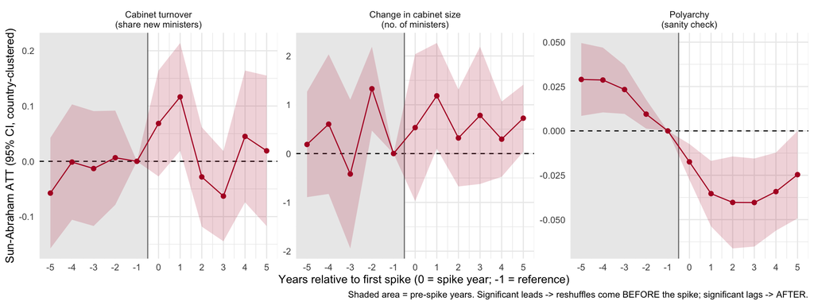

Aggregated ATT (post-spike average)

|  | m_turn | m_size | m_poly |
| --- | --- | --- | --- |
|  | Turnover | Change in cabinet size | Polyarchy |
| Dependent Var.: | turnover | d_cabinet_size | v2x_polyarchy |
| ATT | 0.0281 (0.0378) | 0.6515 (0.4226) | -0.0322*** (0.0083) |
| Fixed-Effects: | ————— | ————— | ——————- |
| country_isocode | Yes | Yes | Yes |
| year | Yes | Yes | Yes |
| _______________ | _______________ | _______________ | ___________________ |
| S.E.: Clustered | by: country_i.. | by: country_i.. | by: country_isocode |
| Observations | 2,560 | 2,474 | 2,560 |
| R2 | 0.24160 | 0.15473 | 0.95628 |
| Within R2 | 0.07522 | 0.13421 | 0.14140 |

How to read this

**Question:** do cabinet purges/reshuffles happen *before* or *after* spikes in executive authoritarian events (DEED Symptom + Precursor events whose actor is the government, head of state, ruling party, cabinet or appointed officials)?

- **Leads (t < 0) above zero** → leaders clear out ministers *first*, then act (consistent with coup-proofing before a power grab).
- **Lags (t ≥ 0) above zero** → reshuffles *follow* the events (fallout, or purging dissenters).
- **Flat everywhere** → cabinet churn and executive aggrandizement are decoupled.

**Caveats:** spike timing is not random, the first-spike rule ignores later spikes, and DEED’s reporting intensity varies by country. Re-run with different `spike_min` / `spike_ratio` values in the setup chunk as a robustness check.

[interactive chart not shown]

V-Dem indices over time

[interactive chart not shown]

Cabinet composition over time

[interactive chart not shown]

Cabinet size and regime type

[interactive chart not shown]

Leaders

[interactive chart not shown]